# The SAD weekend: a Perilous North American Tradition

Keri Kemp

7/20/2020

## Project Overview

To determine how diet affects the gut microbiota, pain, and recovery from inflammatory injury, CD1 mice (ICR:Crl) were fed diets varying in fat source: 1) standard chow (REG; NIH-31, Harlan Teklad), 2) standard American Diet (SAD, Envigo TD.140536), 3) Anti-Inflammatory Diet (AID, Envigo TD.150364). A fourth diet group was included to determine the effect of alternating between the diets in which mice were fed the AID diet Monday to Friday and the SAD diet on Saturday and Sunday. This diet shift aimed to model a pattern of eating that included "cheat days" on the weekends with healthy eating during the week. After 14 weeks of diet exposure, when mice were 16 weeks old, a fecal pellet was collected for sequencing of the microbial 16S rRNA gene.

## Raw Data

The original sequencing reads are available for download via NCBI’s Sequence Read Archive under Bioproject PRJNA615647: https://www.ncbi.nlm.nih.gov/sra/PRJNA615647.

```r
#Load libraries
library(tidyverse)
library(phyloseq)
library(vegan)
library(ape)
library(CoDaSeq)
library(zCompositions)
library(Rmisc)
library(agricolae)
library(rcompanion)
library(knitr)
library(kableExtra)
library(cowplot)
library(genefilter)
library(naniar)
library(car)
library(lmtest)
library(ggfortify)
library(indicspecies)
library(pheatmap)
library(btools)
library(RVAideMemoire)
library(data.table)
library(Hmisc)
library(exactRankTests)
library(compositions)
# Set working directory and file paths
setwd("~/Box/_Sorge_re-analyze")
```

## Import the data into phyloseq

```r
# Set file paths
biom_file = "~/Box/_Sorge_re-analyze/R_input/raw_asv_json.biom"
map_file = "~/Box/_Sorge_re-analyze/R_input/recoverytime_mapping_file.txt"
tree_file = "~/Box/_Sorge_re-analyze/R_input/phylogeny.tre"

# Import biom table, mapping file, and tree file
biom <- import_biom(biom_file, parseFunction = parse_taxonomy_default)
map <- import_qiime_sample_data(map_file)
treefile <- read_tree(tree_file)

# merge in phyloseq object
AID <- merge_phyloseq(biom,map,treefile)

# Inspect the phyloseq object
AID
```

```
## phyloseq-class experiment-level object
## otu_table()   OTU Table:         [ 797 taxa and 18 samples ]
## sample_data() Sample Data:       [ 18 samples by 6 sample variables ]
## tax_table()   Taxonomy Table:    [ 797 taxa by 7 taxonomic ranks ]
## phy_tree()    Phylogenetic Tree: [ 797 tips and 795 internal nodes ]
```

```r
rank_names(AID)
```

```
## [1] "Rank1" "Rank2" "Rank3" "Rank4" "Rank5" "Rank6" "Rank7"
```

```r
# Rename columns in the tax_table
tax <- data.frame(tax_table(AID))
tax.clean <- data.frame(row.names = row.names(tax),
Kingdom = str_replace(tax[,1], "D_0__",""),
Phylum = str_replace(tax[,2], "D_1__",""),
Class = str_replace(tax[,3], "D_2__",""),
Order = str_replace(tax[,4], "D_3__",""),
Family = str_replace(tax[,5], "D_4__",""),
Genus = str_replace(tax[,6], "D_5__",""),
Species = str_replace(tax[,7], "D_6__",""),
stringsAsFactors = FALSE)
tax.clean[is.na(tax.clean)] <- ""
tax_table(AID) <- as.matrix(tax.clean)
rank_names(AID)
```

```
## [1] "Kingdom" "Phylum"  "Class"   "Order"   "Family"  "Genus"   "Species"
```

#### Prune samples with low sequence count from the dataset

```r
# Prune samples with less than 1,000 reads
AID = prune_samples(sample_sums(AID)>=1000, AID)
AID
```

```
## phyloseq-class experiment-level object
## otu_table()   OTU Table:         [ 797 taxa and 18 samples ]
## sample_data() Sample Data:       [ 18 samples by 6 sample variables ]
## tax_table()   Taxonomy Table:    [ 797 taxa by 7 taxonomic ranks ]
## phy_tree()    Phylogenetic Tree: [ 797 tips and 795 internal nodes ]
```

```r
sample_data(AID)
```

```
##     SampleID Seq_count    Diet Week Sex Cage
## F13      F13     70081     REG  16w   F    8
## F14      F14     76553     REG  16w   F    8
## F1        F1     62948 AID-SAD  16w   F    1
## F3        F3     52061 AID-SAD  16w   F    1
## F4        F4     32154     AID  16w   F    2
## F5        F5     53708     AID  16w   F    2
## F6        F6     36672     AID  16w   F    2
## F7        F7     42778     SAD  16w   F    3
## F8        F8     60140     SAD  16w   F    3
## F9        F9     50616     SAD  16w   F    3
## M10      M10     34961     SAD  16w   M    4
## M13      M13     44771     REG  16w   M    5
## M15      M15     86748     REG  16w   M    5
## M1        M1     64523     AID  16w   M    6
## M3        M3     41168     AID  16w   M    6
## M4        M4     61923 AID-SAD  16w   M    7
## M5        M5     57985 AID-SAD  16w   M    7
## M6        M6     44390 AID-SAD  16w   M    7
```

#### Prune rare taxa and fix non-descriptive taxa

```r
# A -- The count value minmum threshold
# k -- The number of samples in which a taxa exceeded A
# A taxa is retained in the dataset if it exceeds the value A in at least k samples.
flist = filterfun(kOverA(2, 5))
AID2 <- filter_taxa(AID, flist, prune=TRUE)
AID2

get_taxa_unique(AID2, "Phylum") #okay
get_taxa_unique(AID2, "Class") #okay
get_taxa_unique(AID2, "Order") #okay
get_taxa_unique(AID2, "Family")
get_taxa_unique(AID2, "Genus")
get_taxa_unique(AID2, "Species")


# change these non-decriptive labels to NA in order to use the following code to "clean" the taxonomy assignments
# make a list of things to replace with an NA
na_strings <- c("unidentified","uncultured bacterium","gut metagenome","uncultured","mouse gut metagenome",
                "uncultured rumen bacterium","uncultured bacterium","uncultured organism","human gut metagenome",
                "uncultured Lactobacillus sp.","uncultured Lactobacillus sp.", "uncultured Rheinheimera sp.",
                "uncultured Lachnospiraceae bacterium","uncultured Clostridiales bacterium","metagenome",
                "uncultured Ruminococcaceae bacterium", "uncultured Bacteroidales bacterium",
                "D\\_3\\_\\_Clostridiales_unclassified","D\\_3\\_\\_Mollicutes_RF39_unclassified",
                "D\\_3\\_\\_Clostridiales_unclassified","D\\_3\\_\\_Mollicutes_RF39_unclassified",
                "D\\_4\\_\\_Lachnospiraceae_unclassified","D\\_4\\_\\_Ruminococcaceae_unclassified",
                "D\\_4\\_\\_Enterobacteriaceae_unclassified","D\\_4\\_\\_Erysipelotrichaceae_unclassified",
                "D\\_5\\_\\_Lachnospiraceae_NK4A136_group_unclassified","D\\_5\\_\\_GCA-900066225_unclassified",
                "D\\_5\\_\\_Ruminococcaceae_UCG-013_unclassified","D\\_5\\_\\_Caproiciproducens_unclassified",
                "D\\_5\\_\\_Peptococcus_unclassified","D\\_5\\_\\_Alistipes_unclassified",
                "D\\_5\\_\\_uncultured_unclassified","D\\_5\\_\\_Coprococcus_3_unclassified",
                "D\\_5\\_\\_Ruminococcaceae_UCG-014_unclassified","D\\_5\\_\\_Pseudomonas_unclassified",
                "D\\_5\\_\\_Acinetobacter_unclassified","D\\_5\\_\\_Streptomyces_unclassified",
                "D\\_5\\_\\_Bacteroides_unclassified","D\\_5\\_\\_Lachnoclostridium_unclassified",
                "D\\_5\\_\\_Ruminococcus_1_unclassified","D\\_5\\_\\_Odoribacter_unclassified")

# https://cran.r-project.org/web/packages/naniar/vignettes/replace-with-na.html
tax <- data.frame(tax_table(AID2))
tax2<-tax %>%
  rownames_to_column( var = "ASV")  %>%
  naniar::replace_with_na_all(condition = ~.x %in% na_strings) %>%
  column_to_rownames (var = "ASV")

####### Fill holes in the tax table
tax.clean <- tax2
tax.clean[is.na(tax.clean)] <- ""
for (i in 1:nrow(tax.clean)){
  if (tax.clean[i,2] == ""){
    kingdom <- paste("unclassified_", tax.clean[i,1], sep = "")
    tax.clean[i, 2:7] <- kingdom
  } else if (tax.clean[i,3] == ""){
    phylum <- paste("unclassified_", tax.clean[i,2], sep = "")
    tax.clean[i, 3:7] <- phylum
  } else if (tax.clean[i,4] == ""){
    class <- paste("unclassified_", tax.clean[i,3], sep = "")
    tax.clean[i, 4:7] <- class
  } else if (tax.clean[i,5] == ""){
    order <- paste("unclassified_", tax.clean[i,4], sep = "")
    tax.clean[i, 5:7] <- order
  } else if (tax.clean[i,6] == ""){
    family <- paste("unclassified_", tax.clean[i,5], sep = "")
    tax.clean[i, 6:7] <- family
  } else if (tax.clean[i,7] == ""){
    tax.clean$Species[i] <- paste("unclassified",tax.clean$Genus[i], sep = "_")
  }
}


tax.clean[is.na(tax.clean)] <- ""
for (i in 1:nrow(tax.clean)){
  if (tax.clean[i,2] == ""){
    kingdom <- paste("Kingdom_", tax.clean[i,1], sep = "")
    tax.clean[i, 2:7] <- kingdom
  } else if (tax.clean[i,3] == ""){
    phylum <- paste("Phylum_", tax.clean[i,2], sep = "")
    tax.clean[i, 3:7] <- phylum
  } else if (tax.clean[i,4] == ""){
    class <- paste("Class_", tax.clean[i,3], sep = "")
    tax.clean[i, 4:7] <- class
  } else if (tax.clean[i,5] == ""){
    order <- paste("Order_", tax.clean[i,4], sep = "")
    tax.clean[i, 5:7] <- order
  } else if (tax.clean[i,6] == ""){
    family <- paste("Family_", tax.clean[i,5], sep = "")
    tax.clean[i, 6:7] <- family
  } else if (tax.clean[i,7] == ""){
    tax.clean$Species[i] <- paste("Genus",tax.clean$Genus[i], sep = "_")
  }
}
tax_table(AID2) <- as.matrix(tax.clean)

AID2
# mean, max and min of sample read counts
min(sample_sums(AID2)) #31863
mean(sample_sums(AID2)) #52861.78
max(sample_sums(AID2)) #83610
```

#### Fig. 5 Barchart

```r
# Transform to relative abundance
AID_norm <- transform_sample_counts(AID2, function(x) 100 * x/sum(x))

# Prepare to make a barchart at order level
AID_Orders <- AID_norm  %>%
  tax_glom(taxrank = "Order") %>% # agglomerate taxa at order level
  psmelt() %>%                    # Melt phyloseq object to long format for producing graphics with ggplot2
  filter(Abundance > 1.0)  %>%    # Filter out orders below 1% in each sample
  arrange(desc(Phylum),desc(Class),desc(Order))

# Check how many Orders
sample_data(AID_Orders)$Order #13

# Sum remaining taxa with a relative abundance < 1% and make a new dataframe
Remainders <- (AID_Orders) %>%
  dplyr::group_by(SampleID,Diet,Sex,Cage) %>%
  dplyr::summarise(Abundance = (100-sum(Abundance))) %>%
  as.data.frame()
Remainders$Order<-"Orders < 1%"
Remainders$Phylum<-"_Orders < 1%"
Remainders$Class<-"_Orders < 1%"
Remainders$Kingdom<-"Bacteria"

# Compile dataframes
AID_barchart <- full_join(AID_Orders,Remainders)
AID_barchart$Order <- as.factor(AID_barchart$Order)

# Reorder based on Phylogeny
AID_barchart <- AID_barchart[with(AID_barchart, order(Phylum,Class,Order)),]
AID_barchart$Order <- as.factor(AID_barchart$Order)
levels(AID_barchart$Order)

# Lock in Order level order
AID_barchart$Order <- factor(AID_barchart$Order,
      levels = c("Orders < 1%","Bifidobacteriales","Coriobacteriales","Bacteroidales",
                "Deferribacterales","Bacillales","Lactobacillales",
                "Clostridiales","Erysipelotrichales", "Enterobacteriales",
                "Pseudomonadales","Mollicutes RF39","Verrucomicrobiales"))

# Lock in Diet level order
AID_barchart$Diet <- factor(sample_data(AID_barchart)$Diet, levels = c("REG","AID","SAD","AID-SAD"))

write.csv(AID_barchart, file = "R_output/AID_barchart.csv")

# Function for making a custom color palette for plotting
library(RColorBrewer)
# Function for plotting colors side-by-side from here: https://cran.r-project.org/web/packages/colorspace/index.html
pal <- function(col, border = "light gray", ...){
  n <- length(col)
  plot(0, 0, type="n", xlim = c(0, 1), ylim = c(0, 1),
       axes = FALSE, xlab = "", ylab = "", ...)
  rect(0:(n-1)/n, 0, 1:n/n, 1, col = col, border = border)
}

colors2=c("grey",
          "#0072b2", "#7BAFDE",            #blue
          "#f2a045","#f0e442",             #orange/yellow
          "#117755","#80c175","#CAE0AB",   #green
          "#44AAAA","#9cdada",             #tourqoise
          "#882E72", "#B178A6",            #purple
          "#d55e00")                       #red
pal(colors2)
```

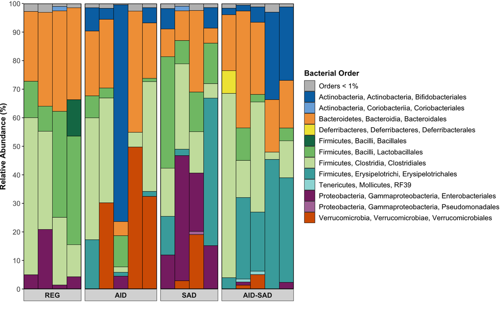

```r
# Plot barchart for Orders for publication
# Export eps as 950 x 500
AID_bc <- ggplot(AID_barchart, aes(x = SampleID, y = Abundance, fill = Order))+
  geom_bar(stat = "identity", colour = "black",size=0.25,width=1)+
  scale_fill_manual(values = colors2,
      labels=c("Orders < 1%","Actinobacteria, Actinobacteria, Bifidobacteriales",
              "Actinobacteria, Coriobacteriia, Coriobacteriales",
              "Bacteroidetes, Bacteroidia, Bacteroidales",
              "Deferribacteres, Deferribacteres, Deferribacterales", "Firmicutes, Bacilli, Bacillales",
              "Firmicutes, Bacilli, Lactobacillales", "Firmicutes, Clostridia, Clostridiales",
              "Firmicutes, Erysipelotrichi, Erysipelotrichales", "Tenericutes, Mollicutes, RF39",
              "Proteobacteria, Gammaproteobacteria, Enterobacteriales",
              "Proteobacteria, Gammaproteobacteria, Pseudomonadales",
              "Verrucomicrobia, Verrucomicrobiae, Verrucomicrobiales"))+
  labs(x = " ",y = "Relative Abundance (%)")+
  labs(fill='Bacterial Order')+
  facet_grid(~Diet, space = "free", scales="free", switch = "x", labeller = labeller(.multi_line = FALSE))+
  theme_bw()+
  theme(plot.title = element_text(hjust = 0.5, size=14,face="bold"))+
  theme(axis.text.x = element_blank(), axis.ticks.x=element_blank())+
  theme(axis.text.y = element_text(size=11), axis.title.y=element_text(size=12,face="bold"))+
  theme(legend.text=element_text(size=11), legend.title=element_text(size=12,face="bold"))+
  theme(panel.border = element_rect(colour="black", fill=NA, size=0.75, linetype="solid"))+
  theme(strip.text.x = element_text(size=11,face="bold"))+
  theme(plot.margin = unit(c(0.2, 0, 0, 0), "cm"))+
  scale_y_continuous(expand = c(0,0), breaks = seq(0, 100, 10))+
  scale_x_discrete(expand = c(0,0))
AID_bc
```

#### Fig 6. Ralative abundance of major Phyla

```r
# Agglomerate at Phylum
Phyla <- AID_norm  %>%
  tax_glom(taxrank = "Phylum") %>%
  psmelt()
# Summarize at Phylum with Rmisc function
Phyla_sum <- summarySE(Phyla, measurevar="Abundance", groupvars=c("Phylum","Diet"))
# Export these tables
write.csv(Phyla,"./R_output/Phyla.csv", row.names=FALSE)
write.csv(Phyla_sum,"./R_output/Phyla_sum.csv", row.names=FALSE)

# Filter for stats and graphing
Actino <- Phyla  %>%
  filter(Phylum == "Actinobacteria")
Bacto <- Phyla  %>%
  filter(Phylum == "Bacteroidetes")
Firm <- Phyla  %>%
  filter(Phylum == "Firmicutes")
Proteo <- Phyla  %>%
  filter(Phylum == "Proteobacteria")

# Set colors (https://www.color-hex.com/color-palette/49436)
cols = c("REG" = "#0072b2", "SAD" = "#d55e00", "AID-SAD" = "#f0e442", "AID" = "#009e73" )

# Re-arrange for plotting
Proteo$Diet <- factor(sample_data(Proteo)$Diet, levels = c("REG","SAD","AID-SAD","AID"))
Proteo_plot <- ggplot(Proteo, aes(x=Diet, y=Abundance,  fill=Diet)) +
  geom_boxplot(outlier.size = 1) + scale_fill_manual(values = cols) + geom_boxplot(outlier.size = 1) +
  labs(x = " ",y = "Proteobacteria \n Relative Abundance (%)") + theme(legend.position="none") + ylim (0,50) +
  theme(panel.grid.major = element_blank(), panel.grid.minor = element_blank()) +
  theme(text = element_text(size=14),axis.text.x=element_text(size=14))+
  theme(axis.title.y = element_text(size=16))

Bacto$Diet <- factor(sample_data(Bacto)$Diet, levels = c("REG","SAD","AID-SAD","AID"))
Bacto_plot <- ggplot(Bacto, aes(x=Diet, y=Abundance,  fill=Diet)) +
  geom_boxplot(outlier.size = 1) + scale_fill_manual(values = cols) + geom_boxplot(outlier.size = 1) +
  labs(x = " ",y = "Bacteroidetes \n Relative Abundance (%)") + theme(legend.position="none") + ylim (0,50) +
  theme(panel.grid.major = element_blank(), panel.grid.minor = element_blank()) +
  theme(text = element_text(size=14),axis.text.x=element_text(size=14)) +
  theme(axis.title.y = element_text(size=16))

Firm$Diet <- factor(sample_data(Firm)$Diet, levels = c("REG","SAD","AID-SAD","AID"))
Firm_plot <- ggplot(Firm, aes(x=Diet, y=Abundance,  fill=Diet)) +
  geom_boxplot(outlier.size = 1) + scale_fill_manual(values = cols) + geom_boxplot(outlier.size = 1) +
  labs(x = " ",y = "Firmicutes \n Relative Abundance (%)") + theme(legend.position="none") + ylim (0,80) +
  theme(panel.grid.major = element_blank(), panel.grid.minor = element_blank()) +
  theme(text = element_text(size=14),axis.text.x=element_text(size=14))+
  theme(axis.title.y = element_text(size=16))

Actino$Diet <- factor(sample_data(Actino)$Diet, levels = c("REG","SAD","AID-SAD","AID"))
Actino_plot <- ggplot(Actino, aes(x=Diet, y=Abundance,  fill=Diet)) +
  geom_boxplot(outlier.size = 1) + scale_fill_manual(values = cols) + geom_boxplot(outlier.size = 1) +
  labs(x = " ",y = "Actinobacteria \n Relative Abundance (%)") + theme(legend.position="none") + ylim (0,80) +
  theme(panel.grid.major = element_blank(), panel.grid.minor = element_blank()) +
  theme(text = element_text(size=14),axis.text.x=element_text(size=14))+
  theme(axis.title.y = element_text(size=16))
```

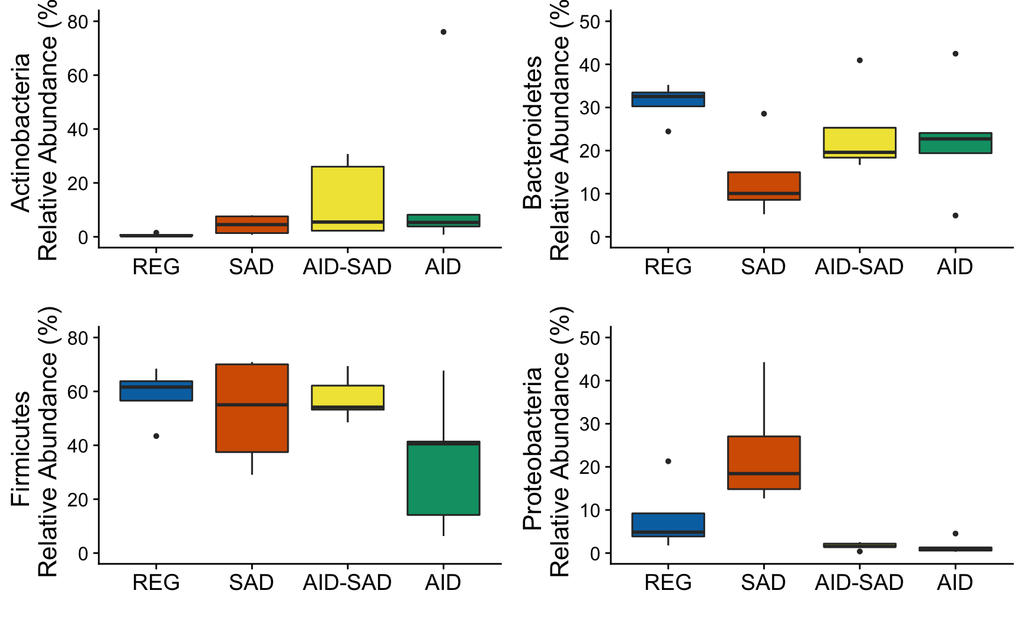

```r
# Combine Plots
# Export eps at 925w x 750h
theme_set(theme_cowplot())
Phyla_Plot <- plot_grid(Actino_plot, Bacto_plot, Firm_plot, Proteo_plot,  align = 'v', ncol = 2)
Phyla_Plot
```

#### Statistics for Figure 6

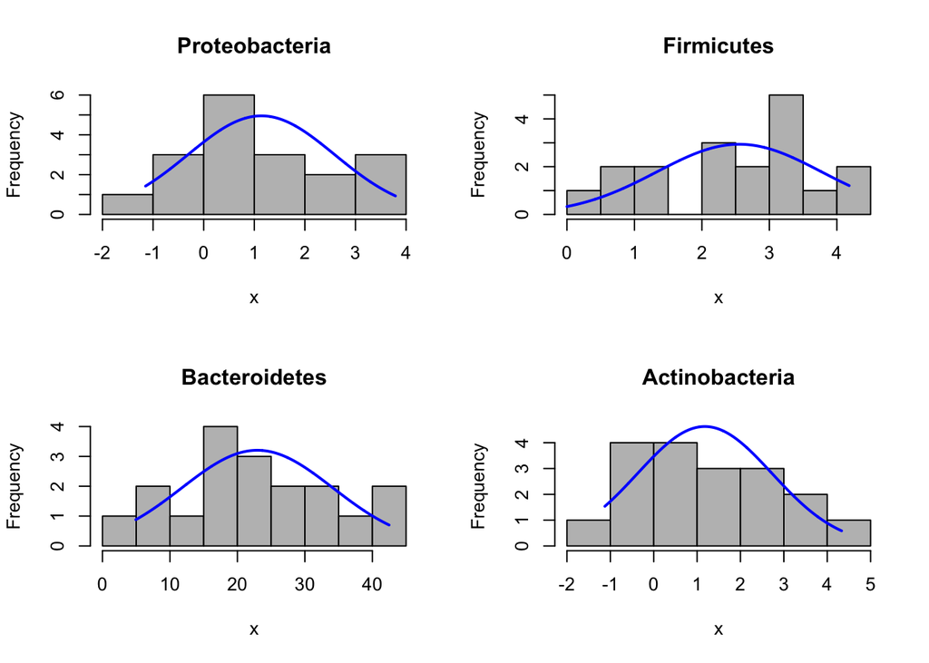

```r
# Histograms
# Create 2x2 plot environment
par(mfrow = c(2, 2))
# Plot each Metric
plotNormalHistogram((log(Proteo$Abundance)), main= "Proteobacteria")
plotNormalHistogram((log(max(Firm$Abundance+1) - Firm$Abundance)), main= "Firmicutes")
plotNormalHistogram(Bacto$Abundance, main= "Bacteroidetes")
plotNormalHistogram((log(Actino$Abundance)), main= "Actinobacteria")
```

```r
# Test for normality
shapiro.test(log(Proteo$Abundance))
```

```
##
##  Shapiro-Wilk normality test
##
## data:  log(Proteo$Abundance)
## W = 0.9615, p-value = 0.6308
```

```r
shapiro.test((log(max(Firm$Abundance+1) - Firm$Abundance)))
```

```
##
##  Shapiro-Wilk normality test
##
## data:  (log(max(Firm$Abundance + 1) - Firm$Abundance))
## W = 0.93137, p-value = 0.2053
```

```r
shapiro.test(Bacto$Abundance)
```

```
##
##  Shapiro-Wilk normality test
##
## data:  Bacto$Abundance
## W = 0.96798, p-value = 0.7589
```

```r
shapiro.test(log(Actino$Abundance))
```

```
##
##  Shapiro-Wilk normality test
##
## data:  log(Actino$Abundance)
## W = 0.96431, p-value = 0.6865
```

#### Actinobacteria

```r
####### Actinobacteria #######
lm <-glm(log(Actino$Abundance) ~ Diet*Cage,  data=Actino)
summary(lm)
```

```
##
## Call:
## glm(formula = log(Actino$Abundance) ~ Diet * Cage, data = Actino)
##
## Deviance Residuals:
##      Min        1Q    Median        3Q       Max
## -1.24038  -0.58652  -0.00289   0.57859   1.73608
##
## Coefficients:
##                  Estimate Std. Error t value Pr(>|t|)
## (Intercept)        1.1467     2.4176   0.474    0.645
## DietSAD           -4.4101     4.7736  -0.924    0.377
## DietAID-SAD       -0.6590     2.5807  -0.255    0.804
## DietAID            2.3756     2.6228   0.906    0.386
## Cage              -0.2679     0.3624  -0.739    0.477
## DietSAD:Cage       1.6022     1.3067   1.226    0.248
## DietAID-SAD:Cage   0.5976     0.3984   1.500    0.164
## DietAID:Cage      -0.1955     0.4392  -0.445    0.666
##
## (Dispersion parameter for gaussian family taken to be 1.182069)
##
##     Null deviance: 40.935  on 17  degrees of freedom
## Residual deviance: 11.821  on 10  degrees of freedom
## AIC: 61.512
##
## Number of Fisher Scoring iterations: 2
```

```r
car::vif(lm)
```

```
##                 GVIF Df GVIF^(1/(2*Df))
## Diet      2722.99645  3        3.736869
## Cage        10.93827  1        3.307306
## Diet:Cage 2567.03956  3        3.700316
```

```r
sstable <-car::Anova(lm , type = c(2), test.statistic=c("F")) #Type II is more powerful when there is no interaction
# The following code adds a column to the sstable object with partial eta-squared estimates for each effect:
sstable$PES <- c(sstable$'Sum Sq'[-nrow(sstable)], NA)/(sstable$'Sum Sq' + sstable$'Sum Sq'[nrow(sstable)])
# Creating an html ANOVA table
options(knitr.kable.NA = '') # this will hide missing values in the kable table
kable(sstable, digits = 3, caption = "Actinobacteria ANOVA table") %>%
  kable_styling(full_width = FALSE)
```

Actinobacteria ANOVA table

|  | Sum Sq | Df | F value | Pr(>F) | PES |
| --- | --- | --- | --- | --- | --- |
| Diet | 16.978 | 3 | 4.788 | 0.026 | 0.590 |
| Cage | 0.214 | 1 | 0.181 | 0.679 | 0.018 |
| Diet:Cage | 10.586 | 3 | 2.985 | 0.083 | 0.472 |
| Residuals | 11.821 | 10 |  |  |  |

```r
# Breusch-Pagan test for heteroskedasticity
# p>0.05, so we fail to reject the null hypothesis that the variance of the residuals is constant
lmtest::bptest(lm)
```

```
##
##  studentized Breusch-Pagan test
##
## data:  lm
## BP = 8.6843, df = 7, p-value = 0.2761
```

```r
# Posthoc multiple comparisons via tukey's HSD test in agricolae
# P-values
agricolae::HSD.test(lm,"Diet", group=TRUE,
                main="Affect of Diet on Actinobacteria", console=TRUE)
```

```
##
## Study: Affect of Diet on Actinobacteria
##
## HSD Test for log(Actino$Abundance)
##
## Mean Square Error:  1.182069
##
## Diet,  means
##
##         log.Actino.Abundance.       std r        Min       Max
## AID                 1.8538283 1.6327857 5 -0.1917072 4.3314122
## AID-SAD             2.0041344 1.2750775 5  0.8115489 3.4251122
## REG                -0.5949834 0.6929145 4 -1.1261144 0.4237196
## SAD                 1.0728992 1.1565814 4 -0.2578103 2.0735840
##
## Alpha: 0.05 ; DF Error: 10
## Critical Value of Studentized Range: 4.326582
##
## Groups according to probability of means differences and alpha level( 0.05 )
##
## Treatments with the same letter are not significantly different.
##
##         log(Actino$Abundance) groups
## AID-SAD             2.0041344      a
## AID                 1.8538283      a
## SAD                 1.0728992     ab
## REG                -0.5949834      b
```

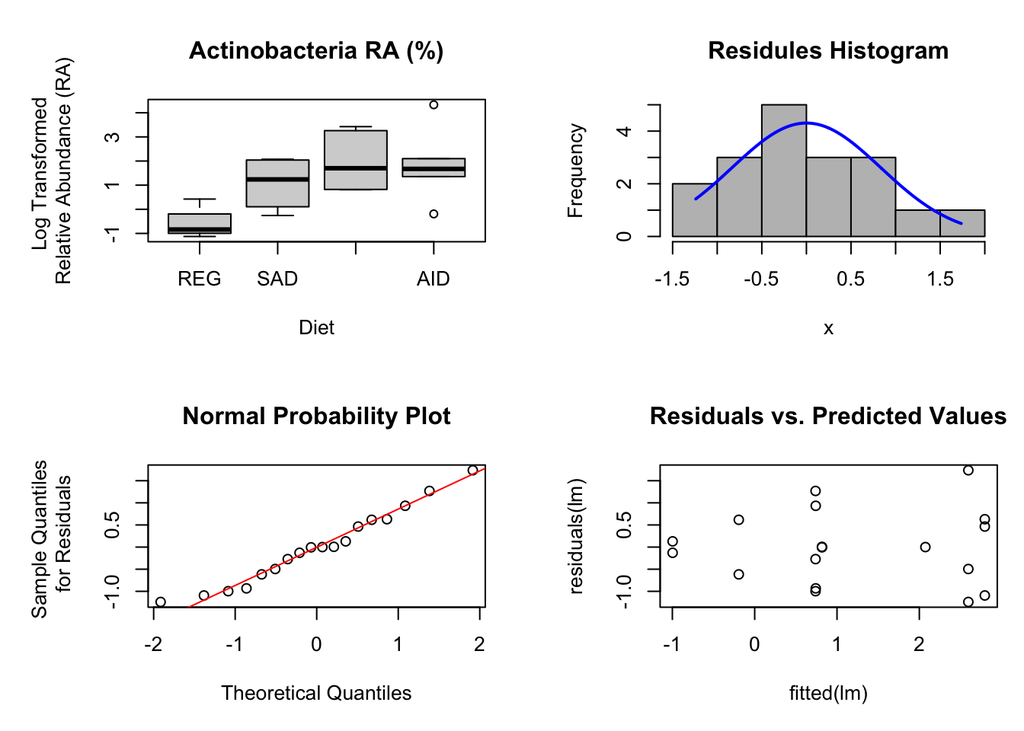

```r
# Create 2x2 plot environment
par(mfrow = c(2, 2), mar=c(5,6,4,1)+.1)
# Plot data
boxplot((log(Actino$Abundance)) ~ Diet, data=Actino,
        ylab="Log Transformed \n Relative Abundance (RA) ",
        xlab="Diet", main = "Actinobacteria RA (%)")
# Plot residules histogram
x = (residuals(lm))
plotNormalHistogram(x, main = "Residules Histogram")
# Normal probability plot
qqnorm(residuals(lm), ylab="Sample Quantiles \n for Residuals", main = "Normal Probability Plot")
qqline(residuals(lm), col="red")
# Simple scatterplot between residuals and predicted values. It should look more or less random.
plot(fitted(lm), residuals(lm), main = "Residuals vs. Predicted Values")
```

#### Bacteroidetes

```r
####### Bacteroidetes #######
lm <- glm(Bacto$Abundance ~ Diet*Cage, data=Bacto)
summary(lm)
```

```
##
## Call:
## glm(formula = Bacto$Abundance ~ Diet * Cage, data = Bacto)
##
## Deviance Residuals:
##      Min        1Q    Median        3Q       Max
## -12.2989   -5.4076   -0.7506    5.3929   12.3340
##
## Coefficients:
##                   Estimate Std. Error t value Pr(>|t|)
## (Intercept)       42.11960   22.58863   1.865   0.0918 .
## DietSAD            6.96983   44.60254   0.156   0.8789
## DietAID-SAD      -10.15674   24.11291  -0.421   0.6825
## DietAID          -31.73049   24.50597  -1.295   0.2245
## Cage              -1.68164    3.38618  -0.497   0.6302
## DietSAD:Cage      -9.27304   12.20904  -0.760   0.4651
## DietAID-SAD:Cage  -0.01012    3.72223  -0.003   0.9979
## DietAID:Cage       5.10667    4.10378   1.244   0.2417
## ---
## Signif. codes:  0 '***' 0.001 '**' 0.01 '*' 0.05 '.' 0.1 ' ' 1
##
## (Dispersion parameter for gaussian family taken to be 103.1959)
##
##     Null deviance: 2133.9  on 17  degrees of freedom
## Residual deviance: 1032.0  on 10  degrees of freedom
## AIC: 141.96
##
## Number of Fisher Scoring iterations: 2
```

```r
car::vif(lm)
```

```
##                 GVIF Df GVIF^(1/(2*Df))
## Diet      2722.99645  3        3.736869
## Cage        10.93827  1        3.307306
## Diet:Cage 2567.03956  3        3.700316
```

```r
sstable <-car::Anova(lm , type = c(2), test.statistic=c("F")) #Type II is more powerful when there is no interaction
# The following code adds a column to the sstable object with partial eta-squared estimates for each effect:
sstable$PES <- c(sstable$'Sum Sq'[-nrow(sstable)], NA)/(sstable$'Sum Sq' + sstable$'Sum Sq'[nrow(sstable)])
# Creating an html ANOVA table
options(knitr.kable.NA = '') # this will hide missing values in the kable table
kable(sstable, digits = 3, caption = "Bacteroidetes ANOVA table") %>%
  kable_styling(full_width = FALSE)
```

Bacteroidetes ANOVA table

|  | Sum Sq | Df | F value | Pr(>F) | PES |
| --- | --- | --- | --- | --- | --- |
| Diet | 578.577 | 3 | 1.869 | 0.199 | 0.359 |
| Cage | 13.041 | 1 | 0.126 | 0.730 | 0.012 |
| Diet:Cage | 451.287 | 3 | 1.458 | 0.284 | 0.304 |
| Residuals | 1031.959 | 10 |  |  |  |

```r
# Breusch-Pagan test for heteroskedasticity
# p>0.05, so we fail to reject the null hypothesis that the variance of the residuals is constant
lmtest::bptest(lm)
```

```
##
##  studentized Breusch-Pagan test
##
## data:  lm
## BP = 12.313, df = 7, p-value = 0.09073
```

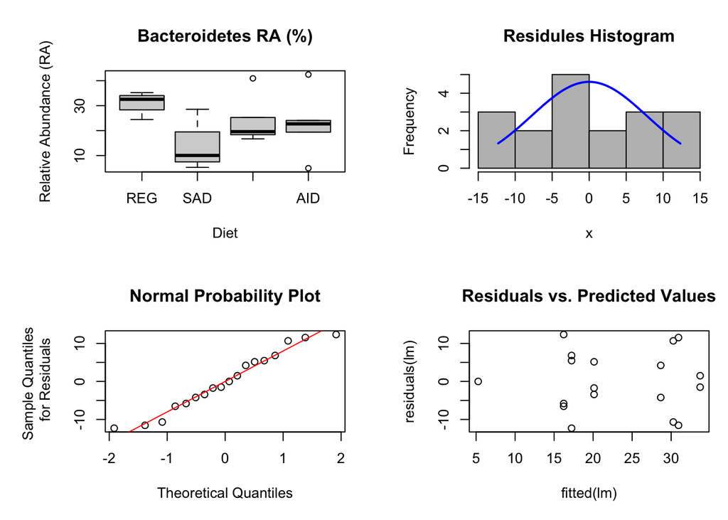

```r
# No post-hoc tests beacuse the global test is not significant)

# Create 2x2 plot environment
par(mfrow = c(2, 2), mar=c(5,6,4,1)+.1)
# Plot data
boxplot(Abundance ~ Diet, data=Bacto,
        ylab="Relative Abundance (RA)",
        xlab="Diet", main = "Bacteroidetes RA (%)")
# Plot residules histogram
x = (residuals(lm))
plotNormalHistogram(x, main = "Residules Histogram")
# Normal probability plot
qqnorm(residuals(lm), ylab="Sample Quantiles \n for Residuals", main = "Normal Probability Plot")
qqline(residuals(lm), col="red")
# Simple scatterplot between residuals and predicted values. It should look more or less random.
plot(fitted(lm), residuals(lm), main = "Residuals vs. Predicted Values")
```

#### Firmicutes

```r
####### Firmicutes #######
lm <- glm((log(max(Firm$Abundance+1) - Firm$Abundance)) ~ Diet*Cage, data=Firm)
summary(lm)
```

```
##
## Call:
## glm(formula = (log(max(Firm$Abundance + 1) - Firm$Abundance)) ~
##     Diet * Cage, data = Firm)
##
## Deviance Residuals:
##      Min        1Q    Median        3Q       Max
## -1.88676  -0.46263   0.08307   0.71005   1.09544
##
## Coefficients:
##                   Estimate Std. Error t value Pr(>|t|)
## (Intercept)       2.377506   2.633010   0.903    0.388
## DietSAD           8.267975   5.199029   1.590    0.143
## DietAID-SAD      -0.588048   2.810685  -0.209    0.838
## DietAID           0.190575   2.856502   0.067    0.948
## Cage             -0.009347   0.394705  -0.024    0.982
## DietSAD:Cage     -2.652023   1.423129  -1.864    0.092 .
## DietAID-SAD:Cage  0.149379   0.433876   0.344    0.738
## DietAID:Cage      0.214829   0.478351   0.449    0.663
## ---
## Signif. codes:  0 '***' 0.001 '**' 0.01 '*' 0.05 '.' 0.1 ' ' 1
##
## (Dispersion parameter for gaussian family taken to be 1.402127)
##
##     Null deviance: 25.376  on 17  degrees of freedom
## Residual deviance: 14.021  on 10  degrees of freedom
## AIC: 64.585
##
## Number of Fisher Scoring iterations: 2
```

```r
car::vif(lm)
```

```
##                 GVIF Df GVIF^(1/(2*Df))
## Diet      2722.99645  3        3.736869
## Cage        10.93827  1        3.307306
## Diet:Cage 2567.03956  3        3.700316
```

```r
sstable <-car::Anova(lm , type = c(2), test.statistic=c("F")) #Type II is more powerful when there is no interaction
# The following code adds a column to the sstable object with partial eta-squared estimates for each effect:
sstable$PES <- c(sstable$'Sum Sq'[-nrow(sstable)], NA)/(sstable$'Sum Sq' + sstable$'Sum Sq'[nrow(sstable)])
# Creating an html ANOVA table
options(knitr.kable.NA = '') # this will hide missing values in the kable table
kable(sstable, digits = 3, caption = "Firmicutes ANOVA table") %>%
  kable_styling(full_width = FALSE)
```

Firmicutes ANOVA table

|  | Sum Sq | Df | F value | Pr(>F) | PES |
| --- | --- | --- | --- | --- | --- |
| Diet | 4.961 | 3 | 1.179 | 0.366 | 0.261 |
| Cage | 0.868 | 1 | 0.619 | 0.450 | 0.058 |
| Diet:Cage | 6.103 | 3 | 1.451 | 0.286 | 0.303 |
| Residuals | 14.021 | 10 |  |  |  |

```r
# Breusch-Pagan test for heteroskedasticity
# p>0.05, so we we fail to reject the null hypothesis that the variance of the residuals is constant
lmtest::bptest(lm)
```

```
##
##  studentized Breusch-Pagan test
##
## data:  lm
## BP = 9.4257, df = 7, p-value = 0.2235
```

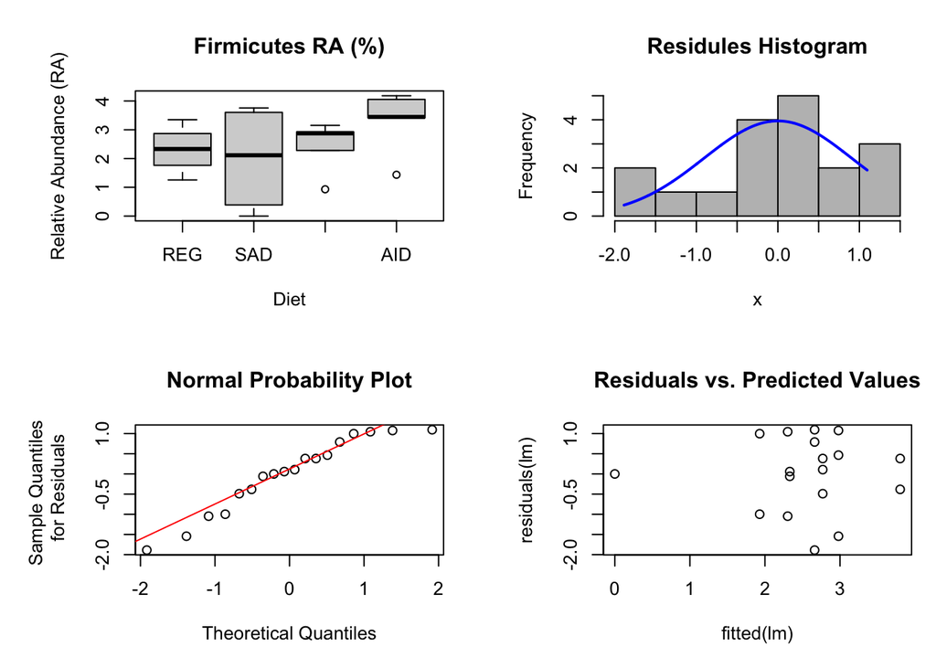

```r
# No post-hoc tests beacuse the global test is not significant)

# Create 2x2 plot environment
par(mfrow = c(2, 2), mar=c(5,6,4,1)+.1)
# Plot data
boxplot((log(max(Firm$Abundance+1) - Firm$Abundance)) ~ Diet, data=Firm,
        ylab="Relative Abundance (RA)",
        xlab="Diet", main = "Firmicutes RA (%)")
# Plot residules histogram
x = (residuals(lm))
plotNormalHistogram(x, main = "Residules Histogram")
# Normal probability plot
qqnorm(residuals(lm), ylab="Sample Quantiles \n for Residuals", main = "Normal Probability Plot")
qqline(residuals(lm), col="red")
# Simple scatterplot between residuals and predicted values. It should look more or less random.
plot(fitted(lm), residuals(lm), main = "Residuals vs. Predicted Values")
```

#### Proteobacteria

```r
####### Proteobacteria #######
lm <- glm(log(Proteo$Abundance) ~ Diet*Cage, data=Proteo)
summary(lm)
```

```
##
## Call:
## glm(formula = log(Proteo$Abundance) ~ Diet * Cage, data = Proteo)
##
## Deviance Residuals:
##      Min        1Q    Median        3Q       Max
## -1.35850  -0.40798  -0.03567   0.43280   1.30257
##
## Coefficients:
##                  Estimate Std. Error t value Pr(>|t|)
## (Intercept)       -1.1122     1.9308  -0.576    0.577
## DietSAD            5.4017     3.8125   1.417    0.187
## DietAID-SAD        0.9106     2.0611   0.442    0.668
## DietAID            1.5850     2.0947   0.757    0.467
## Cage               0.4327     0.2894   1.495    0.166
## DietSAD:Cage      -0.8190     1.0436  -0.785    0.451
## DietAID-SAD:Cage  -0.3202     0.3182  -1.006    0.338
## DietAID:Cage      -0.5643     0.3508  -1.609    0.139
##
## (Dispersion parameter for gaussian family taken to be 0.7539718)
##
##     Null deviance: 35.7209  on 17  degrees of freedom
## Residual deviance:  7.5397  on 10  degrees of freedom
## AIC: 53.418
##
## Number of Fisher Scoring iterations: 2
```

```r
car::vif(lm)
```

```
##                 GVIF Df GVIF^(1/(2*Df))
## Diet      2722.99645  3        3.736869
## Cage        10.93827  1        3.307306
## Diet:Cage 2567.03956  3        3.700316
```

```r
sstable <-car::Anova(lm , type = c(2), test.statistic=c("F")) #Type II is more powerful when there is no interaction
# The following code adds a column to the sstable object with partial eta-squared estimates for each effect:
sstable$PES <- c(sstable$'Sum Sq'[-nrow(sstable)], NA)/(sstable$'Sum Sq' + sstable$'Sum Sq'[nrow(sstable)])
# Creating an html ANOVA table
options(knitr.kable.NA = '') # this will hide missing values in the kable table
kable(sstable, digits = 3, caption = "Proteobacteria ANOVA table") %>%
  kable_styling(full_width = FALSE)
```

Proteobacteria ANOVA table

|  | Sum Sq | Df | F value | Pr(>F) | PES |
| --- | --- | --- | --- | --- | --- |
| Diet | 25.667 | 3 | 11.348 | 0.001 | 0.773 |
| Cage | 0.489 | 1 | 0.648 | 0.440 | 0.061 |
| Diet:Cage | 2.187 | 3 | 0.967 | 0.446 | 0.225 |
| Residuals | 7.540 | 10 |  |  |  |

```r
# Breusch-Pagan test for heteroskedasticity
# p>0.05, so we fail to reject the null hypothesis that the variance of the residuals is constant
lmtest::bptest(lm)
```

```
##
##  studentized Breusch-Pagan test
##
## data:  lm
## BP = 10.302, df = 7, p-value = 0.1721
```

```r
# Posthoc multiple comparisons via tukey's HSD test in agricolae
# P-values
agricolae::HSD.test(lm,"Diet", group=TRUE,
                main="Affect of Diet on Proteobacteria", console=TRUE)
```

```
##
## Study: Affect of Diet on Proteobacteria
##
## HSD Test for log(Proteo$Abundance)
##
## Mean Square Error:  0.7539718
##
## Diet,  means
##
##         log.Proteo.Abundance.       std r        Min      Max
## AID             -0.0009700203 0.9992208 5 -1.1489100 1.512162
## AID-SAD          0.3158486870 0.7419489 5 -0.9492294 0.925857
## REG              1.7000664245 1.0201002 4  0.5873490 3.058624
## SAD              3.0337600861 0.5471604 4  2.5421073 3.789947
##
## Alpha: 0.05 ; DF Error: 10
## Critical Value of Studentized Range: 4.326582
##
## Groups according to probability of means differences and alpha level( 0.05 )
##
## Treatments with the same letter are not significantly different.
##
##         log(Proteo$Abundance) groups
## SAD              3.0337600861      a
## REG              1.7000664245     ab
## AID-SAD          0.3158486870      b
## AID             -0.0009700203      b
```

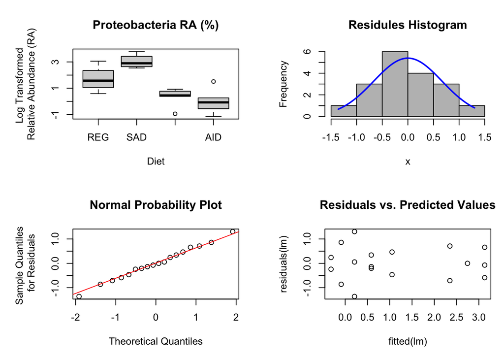

```r
# Create 2x2 plot environment
par(mfrow = c(2, 2), mar=c(5,6,4,1)+.1)
# Plot data
boxplot((log(Proteo$Abundance)) ~ Diet, data=Proteo,
        ylab="Log Transformed \n Relative Abundance (RA) ",
        xlab="Diet", main = "Proteobacteria RA (%)")
# Plot residules histogram
x = (residuals(lm))
plotNormalHistogram(x, main = "Residules Histogram")
# Normal probability plot
qqnorm(residuals(lm), ylab="Sample Quantiles \n for Residuals", main = "Normal Probability Plot")
qqline(residuals(lm), col="red")
# Simple scatterplot between residuals and predicted values. It should look more or less random.
plot(fitted(lm), residuals(lm), main = "Residuals vs. Predicted Values")
```

### Fig 7 Beta Diversity, Panel C

#### Now export otu and taxa tables from phyloseq for codaseq

```r
otu = as(otu_table(AID2), "matrix")
taxon = as(tax_table(AID2), "matrix")
metadata = as(sample_data(AID2), "matrix")
otu = as.data.frame(otu)
alex.in <- otu
taxon = as.data.frame(taxon)
samples = as.data.frame(metadata) # needs to be unique for plotting later
```

#### Imput zero values and conduct the Aitchison center-log-ratio (CLR) transformation.

```r
# count number of zeros in the table
sum(otu == 0)
```

```
## [1] 4548
```

```r
# Replace 0 values with an estimate (because normalization is taking log, can't have 0) using the Bayesian-multiplicative replacement function cmultRepl in Zcompositions. Also transposing here, because we need samples as rows.
d.czm <- zCompositions::cmultRepl(t(otu), method="CZM", label=0)
# Perform the centred log-ratio, or CLR (Aitchison) transformation using CoDaSeq.
# The output will have samples as ROWS
d.clr <- CoDaSeq::codaSeq.clr(d.czm)
```

#### Aitchison distance PCA

```r
# Samples must be ROWs and features/OTUs as COLUMNS. Use the prcomp included in the R core statistics.
d.pcx <- prcomp(d.clr)
```

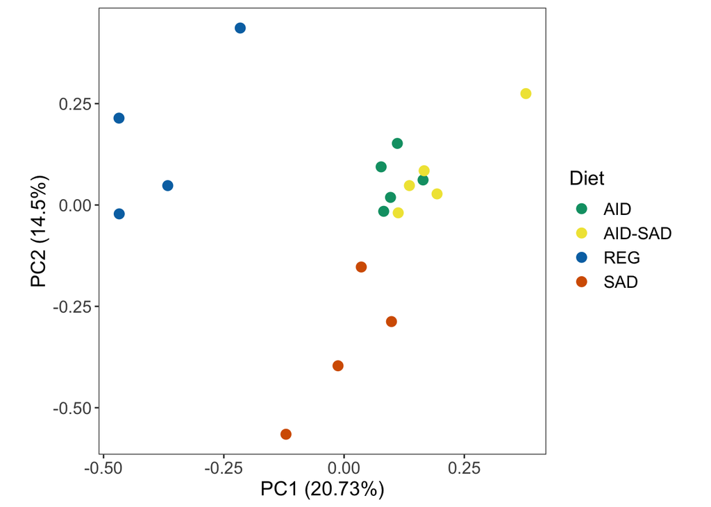

```r
# Plot PCA with ggplot2 (showing samples only)
df_out <- as.data.frame(d.pcx$x)
theme_set(theme_bw()+theme(panel.grid.major = element_blank(),panel.grid.minor = element_blank()))

autoplot(prcomp(d.clr), data = samples, colour = 'Diet')+
  geom_point(aes(color = samples$Diet), size = 3)+
  theme(legend.title = element_text(size=14))+theme(legend.text = element_text(size=12))+
  scale_color_manual(values = cols)+
  labs(color="Diet") +
   theme(aspect.ratio = 1, # set plot to square
        axis.title = element_text(size=14),
        axis.text=element_text(size=12))
```

#### Statistics for Fig 7c (betadiversity)

```r
# Permanova between groups using Aitchison distance.
dist.clr <- dist(d.clr)
perm<-adonis(dist.clr~Diet*Cage, as(sample_data(AID2),"data.frame"))
print(perm)
```

```
##
## Call:
## adonis(formula = dist.clr ~ Diet * Cage, data = as(sample_data(AID2),      "data.frame"))
##
## Permutation: free
## Number of permutations: 999
##
## Terms added sequentially (first to last)
##
##           Df SumsOfSqs MeanSqs F.Model      R2 Pr(>F)
## Diet       3    9627.6  3209.2  2.6205 0.34341  0.001 ***
## Cage       1    1414.1  1414.1  1.1547 0.05044  0.228
## Diet:Cage  3    4747.5  1582.5  1.2922 0.16934  0.097 .
## Residuals 10   12246.3  1224.6         0.43682
## Total     17   28035.4                 1.00000
## ---
## Signif. codes:  0 '***' 0.001 '**' 0.01 '*' 0.05 '.' 0.1 ' ' 1
```

Define the function: Make knitr table from Permanova results. https://rdrr.io/github/TBrach/MicrobiomeX/src/R/Functions.R

```r
get_permanova_table
```

```
## function(adonis) {
##   kable_table <- adonis[[1]]
##   kable_table[["Pr(>F)"]] <- format(kable_table[["Pr(>F)"]], digits = 3)
##   options(knitr.kable.NA = '')
##   knitr::kable(kable_table,
##                digits = 3,
##                caption = "Permanova results") %>%
##   kable_styling(full_width = FALSE)
## }
```

Use the function:

```r
get_permanova_table(perm)
```

Permanova results

|  | Df | SumsOfSqs | MeanSqs | F.Model | R2 | Pr(>F) |
| --- | --- | --- | --- | --- | --- | --- |
| Diet | 3 | 9627.586 | 3209.195 | 2.621 | 0.343 | 0.001 |
| Cage | 1 | 1414.057 | 1414.057 | 1.155 | 0.050 | 0.228 |
| Diet:Cage | 3 | 4747.452 | 1582.484 | 1.292 | 0.169 | 0.097 |
| Residuals | 10 | 12246.312 | 1224.631 |  | 0.437 | NA |
| Total | 17 | 28035.406 |  |  | 1.000 | NA |

```r
# Pairwise adonis
# https:https://www.rdocumentation.org/packages/RVAideMemoire/versions/0.9-69/topics/pairwise.perm.manova
RVAideMemoire::pairwise.perm.manova(dist.clr,samples$Diet,nperm=999,p.method="fdr")
```

```
##
##  Pairwise comparisons using permutation MANOVAs on a distance matrix
##
## data:  dist.clr by samples$Diet
## 999 permutations
##
##         AID   AID-SAD REG
## AID-SAD 0.282 -       -
## REG     0.018 0.016   -
## SAD     0.016 0.016   0.048
##
## P value adjustment method: fdr
```

```r
# Run permdisp to see if statistical differences among communities are driven by differences in variance.
permdisp<-betadisper(dist.clr,samples$Diet)
aov <-anova(permdisp) #this was not significant
# Creating an html ANOVA table
options(knitr.kable.NA = '') # this will hide missing values in the kable table
kable(aov, digits = 3, caption = "Permdisper ANOVA table") %>%
  kable_styling(full_width = FALSE)
```

Permdisper ANOVA table

|  | Df | Sum Sq | Mean Sq | F value | Pr(>F) |
| --- | --- | --- | --- | --- | --- |
| Groups | 3 | 299.746 | 99.915 | 3.351 | 0.05 |
| Residuals | 14 | 417.475 | 29.820 |  |  |

#### Alpha Diversity

```r
# Rarefy to account for differences in sequencing depth among samples. Sample without replacement so that the original
# count value is the maximum possible. Trim OTUs from the dataset that are no longer observed in any sample (have a
# count of zero in every sample).
set.seed(310)
AID_R = rarefy_even_depth(AID2, sample.size = 30000, replace = FALSE, trimOTUs = TRUE)
```

```
## You set `rngseed` to FALSE. Make sure you've set & recorded
##  the random seed of your session for reproducibility.
## See `?set.seed`
```

```
## ...
```

```r
shannon<-estimate_richness(AID_R, split = TRUE, measures=c("Shannon"))
shannon$SampleID <- rownames(shannon)
# Faith's Phylogenetic Diversity (SR = observed species richness)
FaithsPD<-btools::estimate_pd(AID_R)
```

```
## Calculating Faiths PD-index...
```

```r
colnames(FaithsPD)[1] <-"Faiths_PD"
FaithsPD$SampleID <- rownames(FaithsPD)
# Merge tables
alpha_div <- full_join(shannon,FaithsPD, by = "SampleID")
alpha_div <- alpha_div[,c(2,1,3)]
# Add metadata
alpha_div <- full_join(alpha_div,samples, by = "SampleID")
alpha_div$Cage<-as.numeric(as.character(alpha_div$Cage))
# Write out file
write.csv(alpha_div,"./R_output/alpha_div.csv")

# Summarize for stats and plotting
fpd <- Rmisc::summarySE(alpha_div, measurevar="Faiths_PD", groupvars=c("Diet"))
shan <- Rmisc::summarySE(alpha_div, measurevar="Shannon", groupvars=c("Diet"))
# Write out file
write.csv(fpd,"./R_output/Faiths_PD_Summary.csv")
write.csv(shan,"./R_output/Shannon_Summary.csv")

# Histograms
# Create 2x2 plot environment
par(mfrow = c(2, 2))
# Plot each Metric
plotNormalHistogram(alpha_div$Faiths_PD, main= "Faiths PD")
plotNormalHistogram(alpha_div$Shannon, main= "Shannon Index")
plotNormalHistogram((log(alpha_div$Faiths_PD)), main= "log(Faiths PD)")

# Test for normality
shapiro.test(alpha_div$Shannon)
```

```
##
##  Shapiro-Wilk normality test
##
## data:  alpha_div$Shannon
## W = 0.97576, p-value = 0.8962
```

```r
shapiro.test(log(alpha_div$Faiths_PD))
```

```
##
##  Shapiro-Wilk normality test
##
## data:  log(alpha_div$Faiths_PD)
## W = 0.98273, p-value = 0.9737
```

[figure not shown]

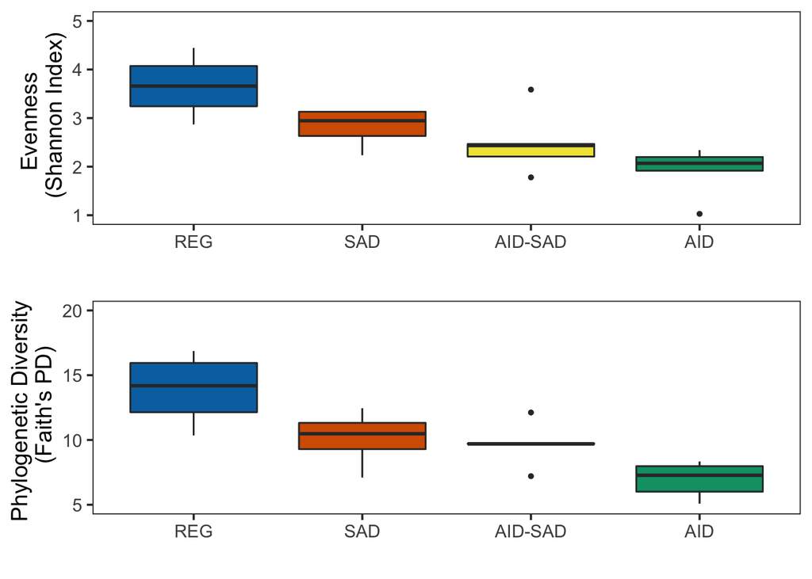

```r
# Re-arrange for plotting
alpha_div$Diet <- factor(sample_data(alpha_div)$Diet, levels = c("REG","SAD","AID-SAD","AID"))

# Set plotting theme
theme_set(theme_bw())

# Plot Shannon
Shannon_plot <- ggplot(alpha_div, aes(x=Diet, y=Shannon,  fill=Diet)) +
  geom_boxplot(outlier.size = 1) + scale_fill_manual(values = cols) + geom_boxplot(outlier.size = 1) +
  labs(x = " ",y = "Evenness \n (Shannon Index)") + theme(legend.position="none") + ylim (1,5) +
  theme(panel.grid.major = element_blank(), panel.grid.minor = element_blank()) +
  theme(text = element_text(size=14),axis.text.x=element_text(size=11))

# Plot Faith's PD
PD_plot <- ggplot(alpha_div, aes(x=Diet, y=Faiths_PD,  fill=Diet)) +
  geom_boxplot(outlier.size = 1) + scale_fill_manual(values = cols) + geom_boxplot(outlier.size = 1) +
  labs(x = " ",y = "Phylogenetic Diversity \n (Faith's PD)") + theme(legend.position="none") + ylim (5,20) +
  theme(panel.grid.major = element_blank(), panel.grid.minor = element_blank()) +
  theme(text = element_text(size=14),axis.text.x=element_text(size=11))

# Combine Plots
theme_set(theme_bw(base_size=14)) # reduce default font size
AlphaDiv_Plot <- plot_grid(Shannon_plot, PD_plot, align = 'v', ncol = 1, axis='l')
AlphaDiv_Plot
```

### Statistics for Fig 7

#### Shannon Index

```r
lm <-glm(Shannon ~ Diet*Cage, data=alpha_div)
summary(lm)
```

```
##
## Call:
## glm(formula = Shannon ~ Diet * Cage, data = alpha_div)
##
## Deviance Residuals:
##      Min        1Q    Median        3Q       Max
## -0.68658  -0.24684   0.08522   0.23595   0.57627
##
## Coefficients:
##                  Estimate Std. Error t value Pr(>|t|)
## (Intercept)        1.3289     1.0005   1.328   0.2136
## DietSAD            4.0084     1.9755   2.029   0.0699 .
## DietAID-SAD        1.8246     1.0680   1.708   0.1184
## DietAID            0.1414     1.0854   0.130   0.8989
## Cage               0.3583     0.1500   2.389   0.0380 *
## DietSAD:Cage      -1.1333     0.5407  -2.096   0.0625 .
## DietAID-SAD:Cage  -0.5015     0.1649  -3.042   0.0124 *
## DietAID:Cage      -0.2360     0.1818  -1.298   0.2233
## ---
## Signif. codes:  0 '***' 0.001 '**' 0.01 '*' 0.05 '.' 0.1 ' ' 1
##
## (Dispersion parameter for gaussian family taken to be 0.2024303)
##
##     Null deviance: 11.8292  on 17  degrees of freedom
## Residual deviance:  2.0243  on 10  degrees of freedom
## AIC: 29.749
##
## Number of Fisher Scoring iterations: 2
```

```r
car::vif(lm)
```

```
##                 GVIF Df GVIF^(1/(2*Df))
## Diet      2722.99645  3        3.736869
## Cage        10.93827  1        3.307306
## Diet:Cage 2567.03956  3        3.700316
```

```r
sstable <-car::Anova(lm , type = c(3), test.statistic=c("F"), contrasts=list(topic=contr.sum, sys=contr.sum))

# The following code adds a column to the sstable object with partial eta-squared estimates for each effect:
sstable$PES <- c(sstable$'Sum Sq'[-nrow(sstable)], NA)/(sstable$'Sum Sq' + sstable$'Sum Sq'[nrow(sstable)])
# Creating an html ANOVA table
options(knitr.kable.NA = '') # this will hide missing values in the kable table
kable(sstable, digits = 3, caption = "Shannon Index ANOVA table") %>%
  kable_styling(full_width = FALSE)
```

Shannon Index ANOVA table

|  | Sum Sq | Df | F values | Pr(>F) | PES |
| --- | --- | --- | --- | --- | --- |
| Diet | 2.645 | 3 | 4.355 | 0.033 | 0.566 |
| Cage | 1.155 | 1 | 5.707 | 0.038 | 0.363 |
| Diet:Cage | 2.759 | 3 | 4.543 | 0.030 | 0.577 |
| Residuals | 2.024 | 10 |  |  |  |

```r
# Posthoc multiple comparisons via tukey's HSD test in agricolae
# P-values
agricolae::HSD.test(lm,"Diet", group=FALSE,
                main="Affect of Diet on Shannon Index", console=TRUE)
```

```
##
## Study: Affect of Diet on Shannon Index
##
## HSD Test for Shannon
##
## Mean Square Error:  0.2024303
##
## Diet,  means
##
##          Shannon       std r      Min      Max
## AID     1.910598 0.5171570 5 1.028330 2.338766
## AID-SAD 2.494757 0.6688949 5 1.779631 3.586563
## REG     3.657672 0.6835124 4 2.870801 4.441946
## SAD     2.818342 0.4250860 4 2.237049 3.146380
##
## Alpha: 0.05 ; DF Error: 10
## Critical Value of Studentized Range: 4.326582
##
## Comparison between treatments means
##
##               difference pvalue signif.        LCL         UCL
## AID - AID-SAD -0.5841584 0.2327         -1.4547165  0.28639965
## AID - REG     -1.7470735 0.0008     *** -2.6704398 -0.82370719
## AID - SAD     -0.9077443 0.0543       . -1.8311106  0.01562202
## AID-SAD - REG -1.1629150 0.0142       * -2.0862813 -0.23954874
## AID-SAD - SAD -0.3235858 0.7132         -1.2469521  0.59978047
## REG - SAD      0.8393292 0.0971       . -0.1339843  1.81264276
```

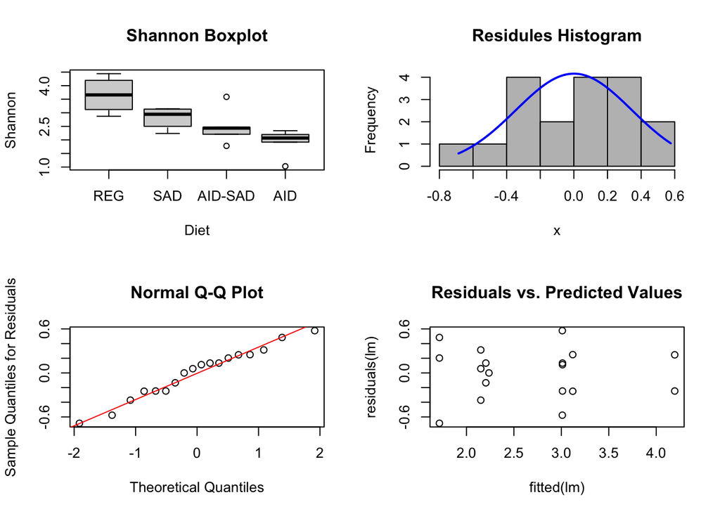

```r
# Create 2x2 plot environment
par(mfrow = c(2, 2))
# Plot data
boxplot(Shannon ~ Diet, data = alpha_div,
        ylab="Shannon",
        xlab="Diet", main = "Shannon Boxplot")
# Plot residules histogram
x = (residuals(lm))
plotNormalHistogram(x, main = "Residules Histogram")
# Normal probability plot
qqnorm(residuals(lm), ylab="Sample Quantiles for Residuals")
qqline(residuals(lm), col="red")
# Simple scatterplot between residuals and predicted values. It should look more or less random.
plot(fitted(lm), residuals(lm), main = "Residuals vs. Predicted Values")
```

#### Faith's PD

```r
lm <-glm((log(Faiths_PD)) ~ Diet*Cage, data=alpha_div)
summary(lm)
```

```
##
## Call:
## glm(formula = (log(Faiths_PD)) ~ Diet * Cage, data = alpha_div)
##
## Deviance Residuals:
##      Min        1Q    Median        3Q       Max
## -0.19884  -0.08560  -0.00375   0.09992   0.18268
##
## Coefficients:
##                  Estimate Std. Error t value Pr(>|t|)
## (Intercept)       1.86517    0.31243   5.970 0.000138 ***
## DietSAD           1.87724    0.61691   3.043 0.012399 *
## DietAID-SAD       0.55317    0.33351   1.659 0.128181
## DietAID          -0.21158    0.33895  -0.624 0.546456
## Cage              0.11525    0.04683   2.461 0.033635 *
## DietSAD:Cage     -0.56061    0.16887  -3.320 0.007749 **
## DietAID-SAD:Cage -0.15017    0.05148  -2.917 0.015380 *
## DietAID:Cage     -0.04118    0.05676  -0.726 0.484767
## ---
## Signif. codes:  0 '***' 0.001 '**' 0.01 '*' 0.05 '.' 0.1 ' ' 1
##
## (Dispersion parameter for gaussian family taken to be 0.01974152)
##
##     Null deviance: 1.70662  on 17  degrees of freedom
## Residual deviance: 0.19742  on 10  degrees of freedom
## AIC: -12.149
##
## Number of Fisher Scoring iterations: 2
```

```r
car::vif(lm)
```

```
##                 GVIF Df GVIF^(1/(2*Df))
## Diet      2722.99645  3        3.736869
## Cage        10.93827  1        3.307306
## Diet:Cage 2567.03956  3        3.700316
```

```r
sstable <-car::Anova(lm , type = c(3), test.statistic=c("F"), contrasts=list(topic=contr.sum, sys=contr.sum))

# The following code adds a column to the sstable object with partial eta-squared estimates for each effect:
sstable$PES <- c(sstable$'Sum Sq'[-nrow(sstable)], NA)/(sstable$'Sum Sq' + sstable$'Sum Sq'[nrow(sstable)])
# Creating an html ANOVA table
options(knitr.kable.NA = '') # this will hide missing values in the kable table
kable(sstable, digits = 3, caption = "Faith's PD ANOVA table") %>%
  kable_styling(full_width = FALSE)
```

Faith's PD ANOVA table

|  | Sum Sq | Df | F values | Pr(>F) | PES |
| --- | --- | --- | --- | --- | --- |
| Diet | 0.574 | 3 | 9.690 | 0.003 | 0.744 |
| Cage | 0.120 | 1 | 6.055 | 0.034 | 0.377 |
| Diet:Cage | 0.421 | 3 | 7.110 | 0.008 | 0.681 |
| Residuals | 0.197 | 10 |  |  |  |

```r
# Posthoc multiple comparisons via tukey's HSD test in agricolae
# P-values
agricolae::HSD.test(lm,"Diet", group=FALSE,
                main="Affect of Diet on Faiths PD", console=TRUE)
```

```
##
## Study: Affect of Diet on Faiths PD
##
## HSD Test for (log(Faiths_PD))
##
## Mean Square Error:  0.01974152
##
## Diet,  means
##
##         X.log.Faiths_PD..       std r      Min      Max
## AID              1.920232 0.2064149 5 1.626539 2.120108
## AID-SAD          2.257680 0.1849878 5 1.975021 2.494947
## REG              2.614278 0.2189835 4 2.337886 2.825163
## SAD              2.294969 0.2398409 4 1.960944 2.521716
##
## Alpha: 0.05 ; DF Error: 10
## Critical Value of Studentized Range: 4.326582
##
## Comparison between treatments means
##
##                difference pvalue signif.         LCL         UCL
## AID - AID-SAD -0.33744813 0.0155       * -0.60931123 -0.06558504
## AID - REG     -0.69404640 0.0001     *** -0.98240075 -0.40569204
## AID - SAD     -0.37473677 0.0117       * -0.66309113 -0.08638241
## AID-SAD - REG -0.35659826 0.0159       * -0.64495262 -0.06824390
## AID-SAD - SAD -0.03728864 0.9779         -0.32564299  0.25106572
## REG - SAD      0.31930963 0.0391       *  0.01535745  0.62326181
```

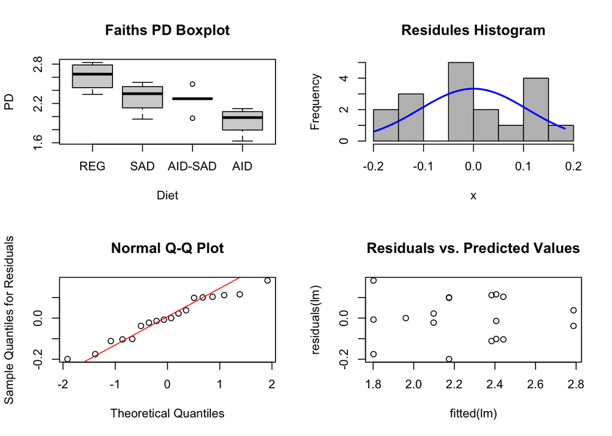

```r
# Create 2x2 plot environment
par(mfrow = c(2, 2))
# Plot data
boxplot((log(Faiths_PD)) ~ Diet, data = alpha_div,
        ylab="PD",
        xlab="Diet", main = "Faiths PD Boxplot")
# Plot residules histogram
x = (residuals(lm))
plotNormalHistogram(x, main = "Residules Histogram")
# Normal probability plot
qqnorm(residuals(lm), ylab="Sample Quantiles for Residuals")
qqline(residuals(lm), col="red")
# Simple scatterplot between residuals and predicted values. It should look more or less random.
plot(fitted(lm), residuals(lm), main = "Residuals vs. Predicted Values")
```

##### ANCOM-II at the genus level

Download the ANCOM v2.1 script from here: https://github.com/FrederickHuangLin/ANCOM

```r
source("~/Box/ANCOM-master/scripts/ancom_v2.1.R")
AID_g = tax_glom(AID2, taxrank = "Genus")
AID_g
```

```
## phyloseq-class experiment-level object
## otu_table()   OTU Table:         [ 86 taxa and 18 samples ]
## sample_data() Sample Data:       [ 18 samples by 6 sample variables ]
## tax_table()   Taxonomy Table:    [ 86 taxa by 7 taxonomic ranks ]
## phy_tree()    Phylogenetic Tree: [ 86 tips and 84 internal nodes ]
```

```r
otu = as(otu_table(AID_g), "matrix")
otu_data = as.data.frame(otu)

# Make new datafram for taxa
ID.taxa <- as.data.frame(tax_table(AID_g))
ID.taxa<- rownames_to_column(ID.taxa, var = "taxa_id")
ID.taxa <- ID.taxa %>% unite("Taxa", 3:7, sep = ", ", remove = FALSE) %>% dplyr::select(taxa_id,Taxa)


metadata = as(sample_data(AID_g), "matrix")
meta_data= as.data.frame(metadata)
meta_data = meta_data %>% dplyr::rename("Sample.ID" = SampleID)
rownames(meta_data) <- c()

# Step 1: Data preprocessing
feature_table = otu_data; sample_var = "Sample.ID"; group_var = NULL
out_cut = 0.05; zero_cut = 0.90; lib_cut = 1000; neg_lb = FALSE
prepro = feature_table_pre_process(feature_table, meta_data, sample_var, group_var,
                                   out_cut, zero_cut, lib_cut, neg_lb)
feature_table = prepro$feature_table # Preprocessed feature table
meta_data = prepro$meta_data # Preprocessed metadata
struc_zero = prepro$structure_zeros # Structural zero info

# Step 2: ANCOM
main_var = "Diet"; p_adj_method = "BH"; alpha = 0.05
adj_formula = "Cage"; rand_formula = NULL
t_start = Sys.time()
res = ANCOM(feature_table, meta_data, struc_zero, main_var, p_adj_method,
            alpha, adj_formula, rand_formula)
t_end = Sys.time()
t_run = t_end - t_start
res_df<-res$out
res2 <- res_df[which(res_df$detected_0.7==TRUE),]
res2 <- left_join(res2,  ID.taxa, by="taxa_id")
print(res2$Taxa)
```

```
## [1] "Firmicutes, Clostridia, Clostridiales, Clostridiaceae 1, Candidatus Arthromitus"
## [2] "Proteobacteria, Gammaproteobacteria, Pseudomonadales, Pseudomonadaceae, Pseudomonas"
## [3] "Firmicutes, Bacilli, Lactobacillales, Streptococcaceae, Lactococcus"
## [4] "Bacteroidetes, Bacteroidia, Bacteroidales, Prevotellaceae, Prevotellaceae UCG-001"
```

##### Indispecies at Genus level

```r
# Extract abundance matrix from the phyloseq object
OTU1 = as(otu_table(AID_g ), "matrix")
# Coerce to data.frame and transpose (need samples as ROWS and ASVs as COLUMNS)
OTUdf = as.data.frame(t(OTU1))

# Make new datafram for taxa
ID.taxa <- as.data.frame(tax_table(AID_g))
ID.taxa<- rownames_to_column(ID.taxa, var = "ID")
ID.taxa <- ID.taxa %>% unite("Taxa", 3:7, sep = ", ", remove = FALSE) %>% dplyr::select(ID,Taxa)

# Prepare mapping file
metadata = as(sample_data(AID_g), "matrix")
mapping_file = as.data.frame(metadata)
# First column (SampleID) should be row names
# Remove SampleID column
mapping_file[1] <- NULL
# Make sure the order of the sample names in both match
nrow(mapping_file)==nrow(OTUdf)
```

```
## [1] TRUE
```

```r
# Create factor name to call for Uniqueclass
OTUs.Diet<-as.factor(mapping_file$Diet)
is.factor(OTUs.Diet) #should be TRUE
```

```
## [1] TRUE
```

```r
# Indicator species analysis by unique site*tree identifier
indisp<-multipatt(x=as.data.frame(OTUdf),
                          cluster=OTUs.Diet,
                          func="IndVal.g",
                          duleg=TRUE,
                          #restcomb = c(1,2,3,4,5,9),
                          control=how(nperm=9999))

# Extract table of stats
indisp.sign<-as.data.table(indisp$sign, keep.rownames=TRUE)
# Add adjusted p-value
indisp.sign[ ,p.value.fdr:=p.adjust(p.value, method="fdr")]
# Now can select only the indicators with adjusted significant p-values
tab1<- indisp.sign[p.value.fdr<=0.05, ]
tab1<-tab1%>%dplyr::rename(ID = rn)

# Add taxa information and write out
indicators_genus<- inner_join(tab1, ID.taxa, by ="ID")
write.csv(indicators,"./R_output/indicator_OTUs_summary_wgenus.csv")
print(indicators_genus)
```

```
##         ID s.AID s.AID-SAD s.REG s.SAD index      stat p.value p.value.fdr
## 1: node144     0         0     1     0     3 0.9825492  0.0012     0.02408
## 2:  node54     0         0     1     0     3 0.9903157  0.0014     0.02408
## 3:  node17     0         0     0     1     4 0.9981027  0.0008     0.02408
## 4:  node55     0         0     1     0     3 1.0000000  0.0009     0.02408
## 5: node207     0         0     1     0     3 0.9745875  0.0008     0.02408
##                                                                                 Taxa
## 1:            Firmicutes, Clostridia, Clostridiales, Lachnospiraceae, Marvinbryantia
## 2:   Firmicutes, Clostridia, Clostridiales, Clostridiaceae 1, Candidatus Arthromitus
## 3:               Firmicutes, Bacilli, Lactobacillales, Streptococcaceae, Lactococcus
## 4: Bacteroidetes, Bacteroidia, Bacteroidales, Prevotellaceae, Prevotellaceae UCG-001
## 5:            Bacteroidetes, Bacteroidia, Bacteroidales, Muribaculaceae, Muribaculum
```

```r
# Get summary information of OTUs that are indicators.
# Note this does not include the FDR adjusted p-values.
print(summary(indisp, alpha=0.05, Bt=0.75 ,indvalcomp=TRUE))
```

```
##
##  Multilevel pattern analysis
##  ---------------------------
##
##  Association function: IndVal.g
##  Significance level (alpha): 0.05
##  Minimum sensitivity (Bt): 0.75
##
##  Total number of species: 86
##  Selected number of species: 23
##  Number of species associated to 1 group: 23
##  Number of species associated to 2 groups: 0
##  Number of species associated to 3 groups: 0
##
##  List of species associated to each combination:
##
##  Group AID  #sps.  1
##            A      B  stat p.value
## node4 0.7629 1.0000 0.873  0.0348 *
##
##  Group AID-SAD  #sps.  2
##             A      B  stat p.value
## node0  0.7088 1.0000 0.842  0.0242 *
## node72 0.5144 1.0000 0.717  0.0284 *
##
##  Group REG  #sps.  18
##              A      B  stat p.value
## node55  1.0000 1.0000 1.000  0.0009 ***
## node54  0.9807 1.0000 0.990  0.0014 **
## node144 0.9654 1.0000 0.983  0.0012 **
## node207 0.9498 1.0000 0.975  0.0008 ***
## node20  0.8875 1.0000 0.942  0.0048 **
## node25  0.8711 1.0000 0.933  0.0054 **
## node92  0.7640 1.0000 0.874  0.0277 *
## node333 1.0000 0.7500 0.866  0.0116 *
## node165 0.7470 1.0000 0.864  0.0094 **
## node48  0.7242 1.0000 0.851  0.0217 *
## node138 0.7149 1.0000 0.846  0.0083 **
## node284 0.9391 0.7500 0.839  0.0141 *
## node196 0.6847 1.0000 0.827  0.0224 *
## node94  0.8630 0.7500 0.805  0.0347 *
## node104 0.6156 1.0000 0.785  0.0212 *
## node179 0.8136 0.7500 0.781  0.0303 *
## node157 0.5960 1.0000 0.772  0.0286 *
## node116 0.5032 1.0000 0.709  0.0263 *
##
##  Group SAD  #sps.  2
##              A      B  stat p.value
## node17  0.9962 1.0000 0.998  0.0008 ***
## node162 0.6476 1.0000 0.805  0.0136 *
## ---
## Signif. codes:  0 '***' 0.001 '**' 0.01 '*' 0.05 '.' 0.1 ' ' 1
## NULL
```

#### Fig 8 Heat map of bacterial indicators of diet at the genus level

```r
AID_g
```

```
## phyloseq-class experiment-level object
## otu_table()   OTU Table:         [ 86 taxa and 18 samples ]
## sample_data() Sample Data:       [ 18 samples by 6 sample variables ]
## tax_table()   Taxonomy Table:    [ 86 taxa by 7 taxonomic ranks ]
## phy_tree()    Phylogenetic Tree: [ 86 tips and 84 internal nodes ]
```

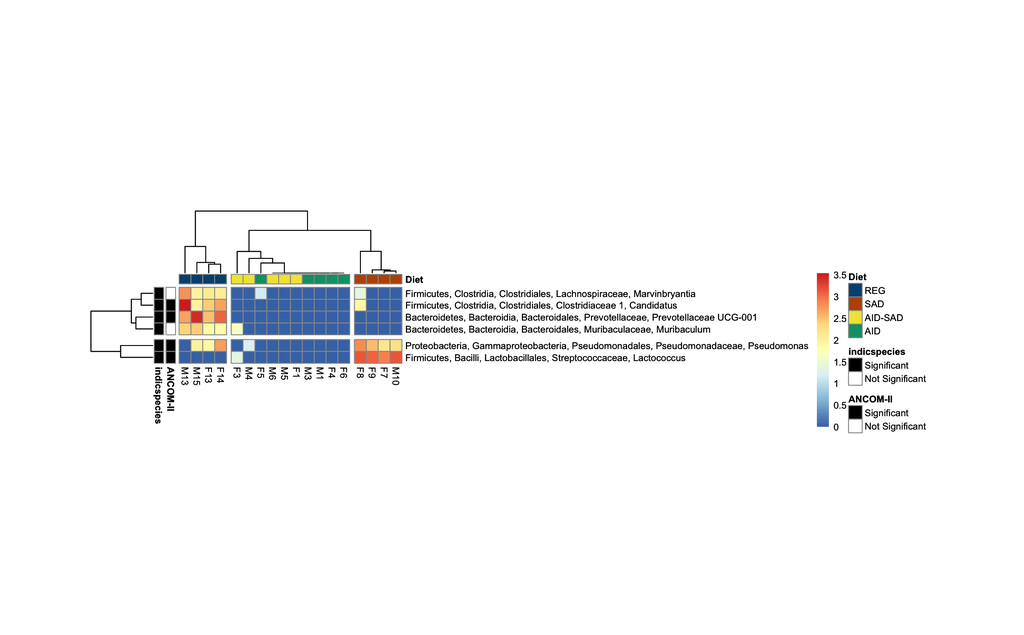

```r
# log(1+x) transformation
AID_gt <- microbiome::transform(AID_g, 'log10p')
otu = as(otu_table(AID_gt), "matrix")
otu = as.data.frame(otu)
metadata = as(sample_data(AID_gt), "matrix")
samples= as.data.frame(metadata)

# Make new datafram for taxa
ID.taxa <- as.data.frame(tax_table(AID_gt))
ID.taxa<- rownames_to_column(ID.taxa, var = "ID")
ID.taxa <- ID.taxa %>% unite("Taxa", 3:7, sep = ", ", remove = FALSE) %>% dplyr::select(ID,Taxa)

# Significant ASVs
list <-c("node144" , "node54", "node17" ,  "node55" , "node207", "node162")

# Subset the otu table to include only the otus that were significant indicators
# Add taxonomy
map <- subset(otu, rownames(otu) %in% list)
map <- map %>% rownames_to_column(var = "ID")
map <- dplyr::inner_join(map, ID.taxa, by ="ID")
map <- map %>% mutate(Taxa = str_replace(Taxa, "Candidatus Arthromitus", "Candidatus"))
# Get ASV names for row annotation
annotation_row <- map %>% dplyr::select(Taxa)
# Get rid of rownames then reassign to ASV name
rownames(map) <- c()
map <-  map %>% column_to_rownames(var = "Taxa")


# Get column order
sample_order <- samples %>%
  arrange(factor(Diet, levels = c("SAD", "REG","AID", "AID-SAD"))) %>%
   dplyr::pull(SampleID)
# Match columns in map to the list in sample_order
map <- map[sample_order]

# Set column annotations
annotation_col <- samples %>%
  arrange(factor(Diet, levels = c("SAD", "REG","AID", "AID-SAD"))) %>%
  column_to_rownames(var = "SampleID") %>%
  dplyr::select(Diet)

# Set row annotations
annotation_row <- read_csv("annotation_row_genus.csv", col_names = TRUE)
annotation_row <-  annotation_row %>% column_to_rownames(var = "Genus")


# https://sashat.me/2017/01/11/list-of-20-simple-distinct-colors/
# Assign colors
my_colour = list(
  Diet = c("REG" = "#00517f", "SAD" = "#bc5300", "AID-SAD" = "#f0e442", "AID" = "#009e73" ),
  "ANCOM-II" = c("Significant"="#000000", "Not Significant"="#ffffff"),
  "indicspecies" = c("Significant"="#000000", "Not Significant"="#ffffff")

)

# Heatmap with pheatmap
# Export eps at 1000x300
hm<-pheatmap(map, clustering_distance_cols = "euclidean", clustering_distance_rows = "euclidean", border_color = "grey60",
             clustering_method = 'complete', fontsize =8, cluster_rows = T, cluster_cols = T,
             annotation_col = annotation_col, annotation_row = annotation_row, annotation_colors = my_colour,
             fontsize_row = 8, fontsize_col = 8, fontsize_number = 8,
             cellwidth = 10, cellheight = 10, cutree_cols =3, cutree_rows = 2
)
hm
```